# Лабораторийн ажил 13-14

## Association Analysis

Холбоо хамаарлын дүрэм сурах нь том өгөгдлийн сан дахь хувьсагчдын хоорондын хамаарлыг илрүүлэх дүрэмд суурилсан (rule-based) машин сургалтын арга юм. **Confidence** эсвэл **lift** зэрэг зарим хэмжүүрүүдийг ашиглан өгөгдлийн багцаас илрүүлсэн хүчтэй харилцааг тодорхойлдог.

Холбоо хамаарлын дүрэм нь **X → Y** хэлбэрийн далд илэрхийлэл бөгөөд **X** ба **Y** нь тусдаа ямар нэг зүйлийн багц байна. Хэрэглэгчийн зан төлөвт үндэслэсэн илүү тодорхой жишээг авч үзвэл, **{Живх} → {Шар айраг}** нь живх худалдаж авдаг хүмүүс шар айраг худалдаж авах магадлалтайг харуулна. Ийм холбоо хамаарлын дүрмийн **"interest"** буюу сонирхолтой байдлыг үнэлэхийн тулд янз бүрийн хэмжүүрүүд боловсруулагдсан байдаг. Энд хийгдэх хэрэгжилт нь **confidence** болон **lift** хэмжүүрүүдийг ашиглана.

**Apriori** алгоритм нь холбоо хамаарлын дүрэм олборлолтын үндсэн техникүүдийн нэг ба энэ нь өгөгдлийн багцаас хамгийн их тохиолддог зүйлсийн багцыг олдог.

## 13.1 Өгөгдлийг ачаалах

```python
import pandas as pd

#read data
data = pd.read_csv("dataset_1.csv", header=None)
data.head()
```

```python
data.shape
```

```python
data.describe()
```

```python
data[1]
```

Хамгийн эрэлттэй 20 барааг харъя.

```python
import numpy as np
# 1. Гүйлгээ бүрийн бүх барааг Numpy Array-д авах
transaction = []
for i in range(0, data.shape[0]):
    for j in range(0, data.shape[1]):
        transaction.append(data.values[i,j])

transaction = np.array(transaction)
print(transaction)
```

```python
# 2. Pandas DataFrame объектод эдгээр утгыг хадгалах
df = pd.DataFrame(transaction, columns=["items"])
# Group By ашиглан хүснэгт дэх бараануудыг тоолохын тулд нэмэлт багана үүсгэн, бараа бүрт 1 утгыг тавих
df["incident_count"] = 1
df.tail()
```

```python
df.shape
```

```python
# 3. Өгөгдлийн багцаас NaN утга бүхий бараануудыг устгах
indexNames = df[df['items'] == "nan" ].index
df.drop(indexNames , inplace=True)
df.shape
```

```python
# 4. Дүрслэлд зориулж бараануудыг бүлэглэн, нийт тоог гаргаж, шинэ DataFrame-д хадгал
df_table = df.groupby("items").sum().sort_values("incident_count", ascending=False).reset_index()
df_table.head(20)
# print(df_table.shape)
```

[output not shown]

## 13.2 Өгөгдлийн урьдчилсан боловсруулалт

**Apriori** алгоритмыг ашиглаж, хамгийн олон давтагдсан зүйлсийн багцыг авахын тулд өгөгдлийн багцыг мөр нь гүйлгээ, багана нь бүтээгдэхүүн байхаар 1-0 матриц болгон хувиргах ёстой. Уг матрицад тухайн гүйлгээгээр бүтээгдэхүүнийг худалдаж авсан бол “1”-ийг, худалдан аваагүй бол “0”-ийг утгыг оруулж кодлоно. Алгоритмыг ашиглахад энэхүү урьдчилсан боловсруулалтыг хийх шаардлагатай.

```python
# Гүйлгээ бүрийг тусдаа жагсаалт (List) болгон хувиргаж, тэдгээрийг Numpy массивт хийх
transaction = []
for i in range(data.shape[0]):
    transaction.append([str(data.values[i,j]) for j in range(data.shape[1])])

transaction = np.array(transaction)
transaction
```

```python
# TransactionEncoder: Байнга тохиолддог зүйлсийн багцыг олборлолохын тулд жагсаалтыг гүйлгээний өгөгдөл рүү хөрвүүлнэ

from mlxtend.preprocessing import TransactionEncoder

te = TransactionEncoder()
te_ary = te.fit(transaction).transform(transaction)
te_ary
```

```python
dataset = pd.DataFrame(te_ary, columns=te.columns_)
dataset
```

```python
dataset.shape
```

[output not shown]

```python
first50 = df_table["items"].head(50).values # Top50 сонгоно
dataset = dataset.loc[:,first50] # Top50 гаргаж авна
dataset
```

```python
dataset.columns  # 50 бараа бүтээгдэхүүн
```

```python
# Өгөгдлийн багцыг 1-0 хөрвүүлж, кодлоно.

def encode_units(x):
    if x == False:
        return 0
    if x == True:
        return 1

dataset = dataset.applymap(encode_units)
dataset.head(10)
```

## 13.3 Алгоритмын хэрэгжүүлэлт

Холбоо хамаарлын дүрэм сурах хэрэгжүүлэлтэнд хамгийн нийтлэг хэрэглэгддэг сан бол **'Mlxtend'**.

### 13.3.1 Support

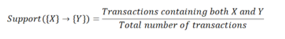

### 13.3.2 Confidence

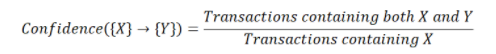

### 13.3.3 Lift

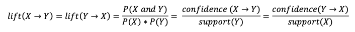

### 13.3.4 Leverage

Гүйлгээнд А зүйл байгаа болон байхгүй байгаа нь В зүйлд хэр зэрэг нөлөөлөх вэ?

Leverage нь А ба В хоёрын хамт тохиолдох магадлал болон хэрвээ А ба В бие даасан байсан бол хүлээгдэж буй давтамжийн зөрүүг тооцдог. Leverage нь lift-тэй төстэй боловч түүний авах утгын муж [-1, 1] тул тайлбарлахад хялбар. Leverage-н 0 утга нь хамааралгүйг илэрхийлнэ.

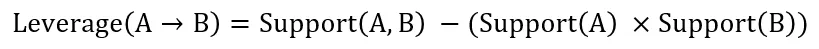

### 13.3.5 Conviction

Conviction хэмжүүр нь тухайн дүрэм санамсаргүй тохиолдлоор гарсан эсэхийг дүгнэхэд тусалдаг. Өөрөөр хэлбэл сонирхолгүй эсвэл хуурамч дүрмийг шүүхэд хэрэглэгддэг. Conviction утга өндөр байна гэдэг нь үр дагавар нь өмнөх үйл явдлаас (A) ихээхэн хамаардаг гэсэн үг юм. Түүний утга 0-с хязгааргүй хооронд байна. Хэрэв зүйлс хамааралгүй буюу бие даасан бол conviction нь 1 байна.

Энэ нь хэрэв A болон B биеэ даасан байсан бол B-гүйгээр A тохиолдох хүлээгдэж буй давтамжийг B-гүйгээр A тохиолдох бодит давтамжид хуваасан харьцаагаар тодорхойлогдоно.

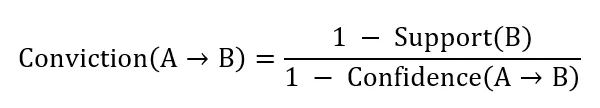

### 13.3.6 Consequents & Antecedents

Холбоо хамаарлын дүрмийн **IF** бүрэлдэхүүнийг өмнөх үе буюу ***antecedent*** гэж нэрлэдэг. **THEN** бүрэлдэхүүнийг үр дагавар буюу **consequent** гэж нэрлэдэг.

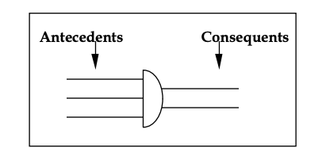

```python
from mlxtend.frequent_patterns import apriori

# Mlxtend-ээр дамжуулан хамгийн их тохиолддог зүйлсийн багцыг гаргаж авах.
# Шүүлтүүрийг хялбар болгох үүднээс урт (length) нэртэй баганыг нэмсэн.

frequent_itemsets = apriori(dataset, min_support=0.01, use_colnames=True)
frequent_itemsets['length'] = frequent_itemsets['itemsets'].apply(lambda x: len(x))
frequent_itemsets
```

Бид доорх хэсгүүдээр дамжуулан зүйлсийн багцыг хялбархан судлах боломжтой

```python
frequent_itemsets[ (frequent_itemsets['length'] == 2) &
                   (frequent_itemsets['support'] >= 0.05) ]
```

```python
frequent_itemsets[ (frequent_itemsets['length'] == 3) ].head()
```

Одоо дүрэм үүсгэхдээ гаргаж авсан байнга тохиолддог зүйлсийн багцыг ашиглана.

```python
from mlxtend.frequent_patterns import association_rules
# association_rules: 'score', 'confidence' болон 'lift' хэмжүүрүүдийг багтаасан холбоо хамаарлын дүрмийн DataFrame-ийг үүсгэдэг.
# Босго оноо болон хэмжүүрийг тодорхойлох замаар дүрмээ үүсгэнэ.
# Хэмжүүр: "lift" гэж тохируулсан.
# Хамааралтай бол 1-ээс дээш оноотой байх шаардлагатай тул босго оноог "1.2" гэж сонгосон.

rules = association_rules(frequent_itemsets, metric="lift", min_threshold=1.2)
rules
```

```python
rules["antecedents_length"] = rules["antecedents"].apply(lambda x: len(x))
rules["consequents_length"] = rules["consequents"].apply(lambda x: len(x))
rules.sort_values("lift",ascending=False)
```

[output not shown]

Өгөгдлөөс илүү их мэдээлэл авахын тулд **confidence** оноог ажиглацгаая!

```python
# confidence утгаар нь эрэмбэлэх

rules.sort_values("confidence",ascending=False)
```

[output not shown]

```python
rules[~rules["consequents"].str.contains("mineral water", regex=False) &
      ~rules["antecedents"].str.contains("mineral water", regex=False)].sort_values("confidence", ascending=False).head(10)
```

[output not shown]

**'round beef'** нь **'mineral water'** бүтээгдэхүүнийг агуулсан болон хассан байдлаар харуулсан хүснэгтийн аль алинд нь дээр байрласан байна. Ийм учраас **'round beef'** бүтээгдэхүүнтэй холбоотой шинэ холбоо хамаарлыг олж, борлуулалтыг нэмэгдүүлэхийн тулд **'round beef'** өмнөх холбоо хамаарлыг авч үзье.

```python
rules[rules["antecedents"].str.contains("ground beef", regex=False) &
      rules["antecedents_length"] == 1].sort_values("confidence", ascending=False).head(10)
```

Дээрх судалгаанаас харахад алгоритм болон **mlxtend** санг ашиглан янз бүрийн байдлыг хялбархан судалж, өгөгдлөөс шинэ холбоо хамаарлыг олж авах боломжтой. Иймээс бусад бүтээгдэхүүнийг (Бид өмнө нь хамгийн их эрэлттэй 50 бүтээгдэхүүнийг сонгосон) тооцоонд оруулах эсвэл шалгуурын босгыг өөрчлөх замаар судалгааг илүү нарийвчилж болно. Бид зөв явж байгаа гэдэгтээ итгэлтэй байхын тулд өгөгдлийн дүрслэл болон (эсвэл) өгөгдлийг цэвэрлэх (шаардлагатай бол) алхмуудад хангалттай ач холбогдол өгөх ёстой.

# Даалгавар

**Ашиглах өгөгдөл**: dataset_2.csv

1. Өгөгдлийг Dataframe-д авч, эхний 5 бичлэгийг хадгал
2. Гүйлгээ бүрийг дараах жишээнд харуулсан шиг тусдаа жагсаалт (List) болгон хувирга.

```
dataset = [['Apple', 'Beer', 'Rice', 'Chicken'],
           ['Apple', 'Beer', 'Rice'],
           ['Apple', 'Beer'],
           ['Apple', 'Bananas'],
           ['Milk', 'Beer', 'Rice', 'Chicken'],
           ['Milk', 'Beer', 'Rice'],
           ['Milk', 'Beer'],
           ['Apple', 'Bananas']]
```

3. Жагсаалтыг гүйлгээний өгөгдөл рүү хөрвүүлнэ. Өөрөөр хэлбэл оролтын өгөгдлийг (жагсаалтын жагсаалтыг) one-hot кодлогдсон NumPy boolean массив руу хөрвүүлнэ.
4. (3)-н үр дүнд гарсан массивыг DataFrame-д хадгалж, эхний 10 мөрийг хэвлэж хар.
5. Хамгийн их тохиолддог барааны багцыг гарга. (min_support=0.01)
6. (5)-г support-н утгаар эрэмбэлж харуул.
7. 2 бараанаас тогтсон (2-itemsets), support >=0.05 байх багцуудыг харуул.
8. (5)-н үр дүн буюу гаргаж авсан байнга тохиолддог зүйлсийн багцыг ашиглан дүрмээ үүсгэ. (metric='confidence', min_threshold=0.7)
9. 'confidence' оноогоор нь эрэмбэл.